# 2-eda-1

Author

Andriy Koval, Oleksandr Koval

**Load packages**

```r
library(tidyverse)
library(ggplot2)
library(dplyr)
library(readr)
ds3 <- readRDS("../../data-private/derived/university-ranking/1-scribe-ds3.rds")
#file_path <- "/data-private/derived/university-ranking/"


print(ds3)
getwd()
summary(ds3)
```

[output not shown]

# Analyzing Top 50 Universities

We focus on the subset containing the top 50 universities according to EuroOsvita ranking for 2024.

# 1 - Applications and rank

Among these 50, are there universities that stand out by the number of applications received? How is that related to the overall rank?

There are four universities that stand out(KPI, LKPI, LNU, KNUTS). There are all at the top of the ranking list and received substantially larger number of applications than any other universities.

**Index vs total applications**

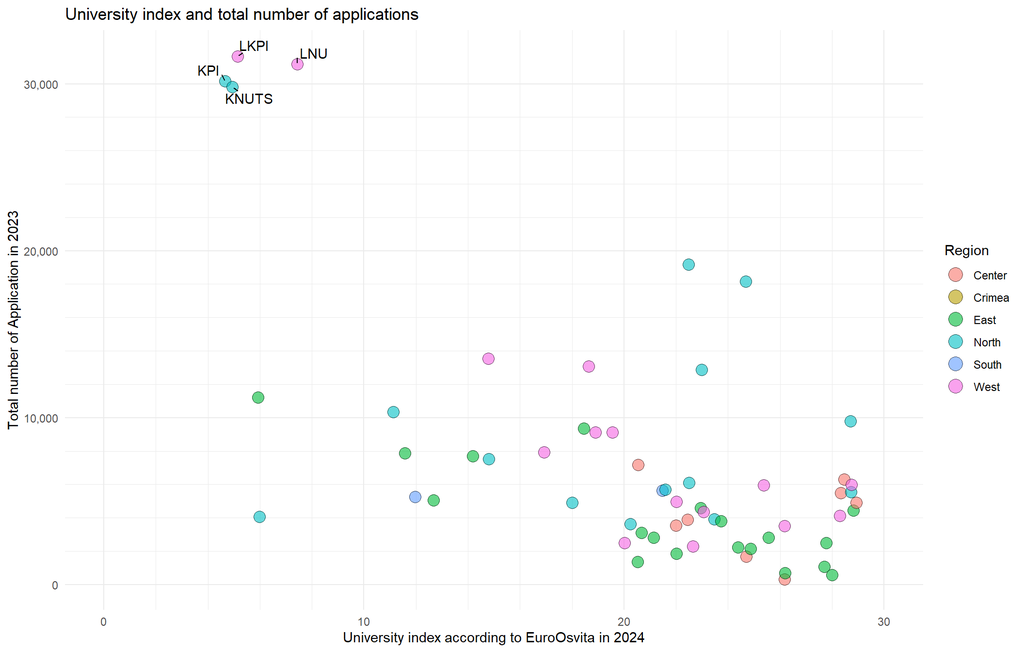

```r
d1 <-
  ds3 %>%
  mutate(
    top4 = case_when(
      application_total_count > 25000 ~ TRUE
      ,TRUE ~ FALSE
    )
  ) %>%
  filter(!is.na(region))

g1 <-
  d1 %>%
  ggplot(aes(x = index_2024, y = application_total_count, fill = region))+
  geom_point(size = 4, shape = 21, color = "black", alpha = .6)+
  # geom_text(aes(label = school_abb))+
  ggrepel::geom_text_repel(
    aes(label = school_abb)
    ,data = . %>% filter(top4)
    ,min.segment.length = .1
  )+
  # scale_color_manual(values = c("TRUE"="red","FALSE"="black"))+
  scale_x_continuous(
    limits = c(0, 30)
    ,minor_breaks = seq(0, 30, 2)
  )+
  scale_y_continuous(
    labels = scales::comma_format()
    ,breaks = seq(0,30000,10000)
    ,minor_breaks = seq(0, 30000, 2000)
  )+
  labs(
    title = "University index and total number of applications"
    ,y = "Total number of Application in 2023"
    ,x = "University index according to EuroOsvita in 2024"
  )+
  guides(
    fill = guide_legend(override.aes = list(size = 5)) # Adjust line thickness in legend
  )+
  labs(
    fill = "Region"
  ) +
  theme_minimal()
g1
```

# 2 - Location is important?

We suspect that the size of the city in which the university is located will influence the number of application submitted to that university. Let’s test this hypothesis visually.

We will consider 2 cases:

1 - Full sample of 200 universities

2 - Sub-sample of Top 50 universities

**Prepering data**

```r
# ds3 %>% glimpse()
d2 <-
  ds3 %>%
  # filter(school_id <= 50) %>%
  select(school_id, school_abb, student_count, application_total_count, city_population, city, region) %>%
  mutate(
    student_body_pct_city = student_count / city_population
    ,application_pct_city = application_total_count/ city_population
  ) %>%
mutate(
  top5 = case_when(
    student_count > 30000 & city_population > 2000000 ~ TRUE,
    TRUE ~ FALSE
  )
)

d21 <-
  d2 %>%
  filter(school_id <= 50)
```

**Making graphs**

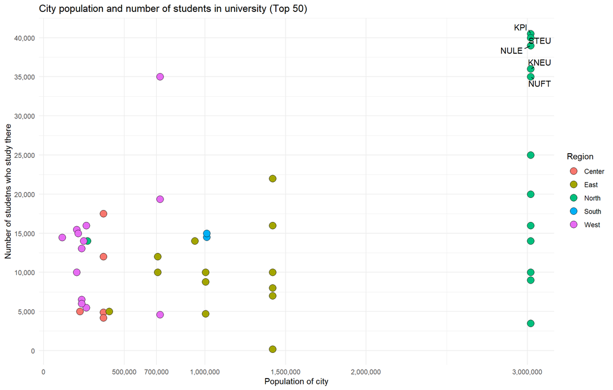

```r
g2 <-
  d21 %>%
  ggplot(aes(x=city_population, y = student_count, fill = region))+
  geom_point(size = 4, shape = 21, color = "black")+
  ggrepel::geom_text_repel(
    aes(label = school_abb)
    ,data = . %>% filter(top5)
    ,min.segment.length = .1
  ) +
  scale_x_continuous(
        labels = scales::comma_format()
        ,breaks = c(seq(0, 3000000, 1000000), 500000, 700000, 1500000)
        ,minor_breaks = seq(0, 3000000, 500000)
  ) +
  scale_y_continuous(
            labels = scales::comma_format()
            ,breaks = seq(0, 40000, 5000)
  ) +
  labs(
    x = "Population of city"
    ,y = "Number of studetns who study there"
    , title = "City population and number of students in university (Top 50)"
    ,fill = "Region"
  ) +
  theme_minimal()
g2
```

**Making graphs**

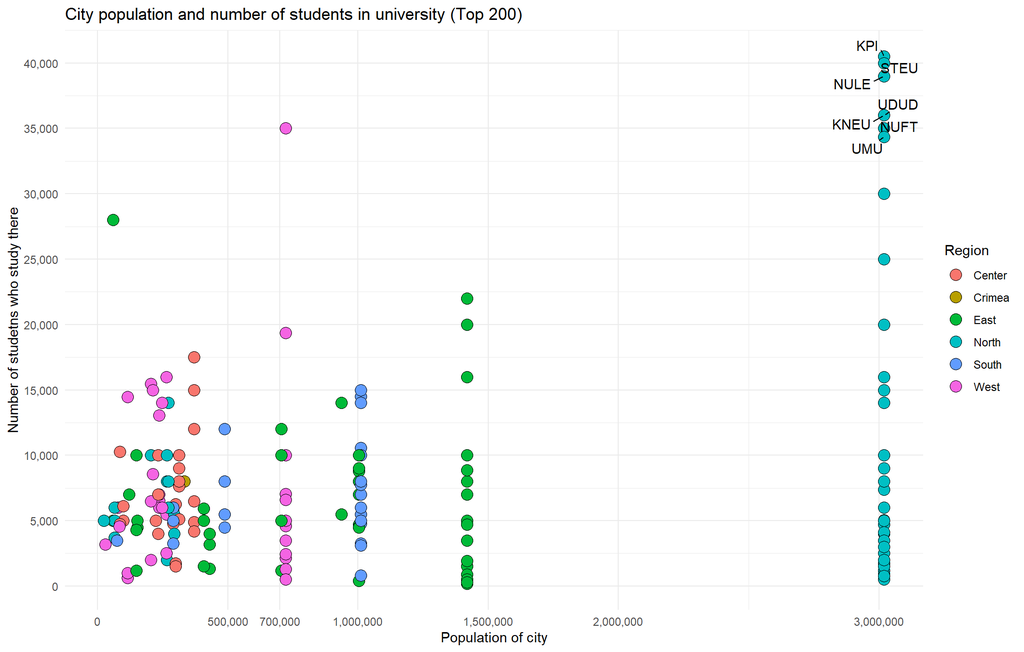

```r
g2_top50 <-
  d2 %>%
  ggplot(aes(x=city_population, y = student_count, fill = region))+
  geom_point(size = 4, shape = 21, color = "black")+
  ggrepel::geom_text_repel(
    aes(label = school_abb)
    ,data = . %>% filter(top5)
    ,min.segment.length = .1
  ) +
  scale_x_continuous(
        labels = scales::comma_format()
        ,breaks = c(seq(0, 3000000, 1000000), 500000, 700000, 1500000)
        ,minor_breaks = seq(0, 3000000, 500000)
  ) +
  scale_y_continuous(
            labels = scales::comma_format()
            ,breaks = seq(0, 40000, 5000)
  ) +
  labs(
    x = "Population of city"
    ,y = "Number of studetns who study there"
    , title = "City population and number of students in university (Top 200)"
    ,fill = "Region"
  ) +
  theme_minimal()
g2_top50
```

We do not observe a clear linear relationship between these two variables. Universities tend to have similar range of total student body regardless of the size of the city in which they are located. One notable exception is Kyiv in which the range is significantly larger.

# 3 - Student and application counts

We will see the different relationship in each region of Ukraine between university’s number of students and number of applications.

But generally we observe a positive relationship: larger universities receive more applications.

**Making graph**

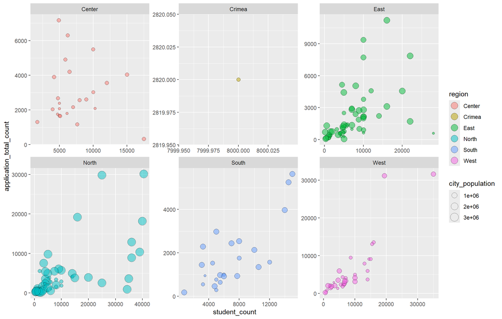

```r
# DRAFT
# ds3 %>%
#   group_by(region, oblast, city, city_population) %>%
#   summarise(
#     count = n()
#   ) %>%
#   ungroup() %>%
#   knitr::kable()

#   d2 %>%
#   ggplot(aes(x=city_population, y = application_total_count))+
#   geom_point()
# # it looks like the size of the city does not influece the number of applications recieved by a university
# # it looks like the size of the city does not influece the number of applications recieved by a university
#   d2 %>%
#   ggplot(aes(x=city_population, y = student_body_pct_city))+
#   geom_point()
#
#   d2 %>%
#   ggplot(aes(x=city_population, y = application_pct_city))+
#   geom_point()
#

g3 <-
 ds3 %>%
    ggplot(aes(student_count, y = application_total_count, fill = region, size = city_population))+
    geom_point(shape = 21, color = "black", alpha = .5)+
    guides(
      fill = guide_legend(override.aes = list(size = 5)) # Adjust line thickness in legend
    )+
    facet_wrap(facets = "region", scales = "free")
g3
```

# 4 - Geography of Education

Let as examine the ratio of student bodies to the population of the cities in which universities are located.

**Preparing data**

```r
# ds3 %>% glimpse()
# What cities are present in the data? (42)
# How many universities are in each city? (1-43)
# How many students are in each city/regions ()
# What percent of city's population are students?
d1 <-
  ds3 %>%
  group_by(region, oblast, city) %>%
  # group_by(oblast) %>%
  summarize(
    school_count = n_distinct(school_id)
    ,student_count = sum(student_count, na.rm = T)
  ) %>%
  ungroup() %>%
  arrange(region, oblast,  desc(school_count))
d1

d_city_pop <-
  ds3 %>%
  distinct(city, city_population )

d2 <-
  d1 %>%
  left_join(d_city_pop) %>%
  ungroup() %>%
  mutate(
    pop_student_prop = student_count/city_population
  )

# d2 %>% print(n=Inf)
```

**Making graph**

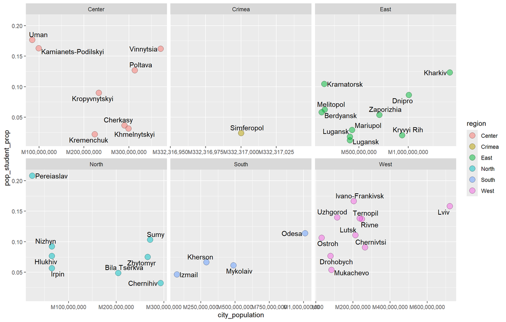

```r
# # what university has the highest demand for budget places?
# ds3 %>% glimpse()
# d1 <-
#   ds3 %>%
#   mutate(
#     budget_ratio = application_budget_count/ application_total_count
#   )
# d1
#
# g1 <-
#   d1 %>%
#   ggplot(aes(x=score_mean, y = budget_ratio, color = oblast))+
#   # scale_x_continuous(limits = c(0,51))
#   geom_point()+
#   labs(
#     title  = "Relationship between average submitted score and share of application for public funding"
#     ,x = "Mean score of the application"
#     ,y = "Share of application for public fundtion"
#   )
# g1
g1 <-
  d2 %>%
  filter(! city %in% c("Kyiv","Pokrovsk") ) %>% # Outliers
  ggplot(aes(x = city_population, y = pop_student_prop, fill = region ))+
  geom_point(shape = 21, color = "black", alpha = .5, size = 4) +
  facet_wrap(facets = "region", scales = "free_x")+
  scale_x_continuous(labels = scales::comma_format(scale = 1000, prefix = "M"))+
  ggrepel::geom_text_repel(aes(label = city),max.overlaps = 30)
g1
```